# Final Report for Data Mining & Test Mining

Breadbasket Project

Lucy Bridges, Megan Morano, Wyatt Smith, Chris Willman

## Introduction

The BreadBasket dataset is a set of recorded transactions from a grocery store/bakery type of place. Our team decided to explore this dataset and use the arules library to conduct association rules analysis. We wanted to see which items were bought the most both in general and at different times of day. After that, we wanted to see which items were most commonly associated with each other in these transactions. Lastly, we created visual aids to help interpret our findings.

## Data Exploration

#### Exploration Based on Time of Day

These two tables give us an idea of the range of times that purchases are made.They also gave us a reference point for attribute names and types.

```r
# top end for time spectrum
BreadBasketData %>%
  arrange(Time) %>%
  head(20)
```

|  | Date | Time | Transaction | Item |
| --- | --- | --- | --- | --- |
| 1 | 2017-01-01 | 01:21:05 | 4090 | Bread |
| 2 | 2016-11-21 | 07:29:57 | 1800 | Coffee |
| 3 | 2016-11-04 | 07:32:33 | 437 | Medialuna |
| 4 | 2016-11-14 | 07:39:27 | 1275 | Coffee |
| 5 | 2016-11-15 | 07:42:27 | 1342 | Coffee |
| 6 | 2016-11-15 | 07:42:27 | 1342 | Medialuna |
| 7 | 2016-11-28 | 07:44:17 | 2217 | Coffee |
| 8 | 2016-11-28 | 07:44:17 | 2217 | Bread |
| 9 | 2016-11-03 | 07:46:50 | 340 | Coffee |
| 10 | 2016-11-03 | 07:46:50 | 340 | Bread |

[output cut: 10 more lines]

```r
# bottom end for time spectrum
BreadBasketData %>%
  arrange(Time) %>%
  tail(20)
```

|  | Date | Time | Transaction | Item |
| --- | --- | --- | --- | --- |
| 21274 | 2016-12-17 | 20:31:38 | 3385 | Pintxos |
| 21275 | 2017-02-04 | 20:39:29 | 6027 | Tshirt |
| 21276 | 2016-12-17 | 20:40:07 | 3386 | Coke |
| 21277 | 2016-12-17 | 20:40:07 | 3386 | Pintxos |
| 21278 | 2017-02-04 | 20:46:29 | 6028 | Tshirt |
| 21279 | 2017-02-04 | 20:46:29 | 6028 | Postcard |
| 21280 | 2016-12-17 | 21:42:13 | 3387 | Hot chocolate |
| 21281 | 2016-12-17 | 21:42:13 | 3387 | Hot chocolate |
| 21282 | 2017-04-08 | 21:43:15 | 9637 | Vegan Feast |
| 21283 | 2017-04-05 | 22:15:55 | 9448 | Juice |

[output cut: 10 more lines]

Here, we filter data into three categories: morning, afternoon, evening.

```r
BreadBasketData <- BreadBasketData %>%
  na_if("NONE")

MorningData <- BreadBasketData %>%
                filter(Time >= "00:00:00" & Time <= "11:59:59")   #before 12pm
AfternoonData <- BreadBasketData %>%
                  filter(Time >= "12:00:00" & Time <= "15:59:59")   #12 to 4pm
EveningData <- BreadBasketData %>%
                filter(Time >= "16:00:00" & Time <= "23:59:59")   #after 4pm
```

#### Confirming Top and Bottom End of Time Ranges

Morning Data Exploration

```r
MorningData %>%
  arrange(Time) %>%
  head(10)
```

|  | Date | Time | Transaction | Item |
| --- | --- | --- | --- | --- |
| 1 | 2017-01-01 | 01:21:05 | 4090 | Bread |
| 2 | 2016-11-21 | 07:29:57 | 1800 | Coffee |
| 3 | 2016-11-04 | 07:32:33 | 437 | Medialuna |
| 4 | 2016-11-14 | 07:39:27 | 1275 | Coffee |
| 5 | 2016-11-15 | 07:42:27 | 1342 | Coffee |
| 6 | 2016-11-15 | 07:42:27 | 1342 | Medialuna |
| 7 | 2016-11-28 | 07:44:17 | 2217 | Coffee |
| 8 | 2016-11-28 | 07:44:17 | 2217 | Bread |
| 9 | 2016-11-03 | 07:46:50 | 340 | Coffee |
| 10 | 2016-11-03 | 07:46:50 | 340 | Bread |

```r
MorningData %>%
  arrange(Time) %>%
  tail(10)
```

|  | Date | Time | Transaction | Item |
| --- | --- | --- | --- | --- |
| 8710 | 2017-02-20 | 11:59:57 | 6908 | Tea |
| 8711 | 2017-02-20 | 11:59:57 | 6908 | Coffee |
| 8712 | 2017-02-20 | 11:59:57 | 6908 | Pastry |
| 8713 | 2017-02-20 | 11:59:57 | 6908 | NA |
| 8714 | 2017-04-09 | 11:59:57 | 9665 | Coffee |
| 8715 | 2017-04-09 | 11:59:57 | 9665 | Juice |
| 8716 | 2017-04-09 | 11:59:57 | 9665 | Spanish Brunch |
| 8717 | 2016-11-13 | 11:59:58 | 1238 | Bread |
| 8718 | 2016-11-13 | 11:59:58 | 1238 | Bread |
| 8719 | 2016-11-13 | 11:59:58 | 1238 | Brownie |

> Seeing a lot of coffee and bread here

Afternoon Data Exploration

```r
AfternoonData %>%
 arrange(Time) %>%
 head(10)
```

|  | Date | Time | Transaction | Item |
| --- | --- | --- | --- | --- |
| 1 | 2017-01-29 | 12:00:07 | 5589 | Bread |
| 2 | 2017-01-29 | 12:00:07 | 5589 | Bread |
| 3 | 2017-02-25 | 12:00:08 | 7173 | Tiffin |
| 4 | 2017-02-25 | 12:00:08 | 7173 | Medialuna |
| 5 | 2017-01-14 | 12:00:12 | 4677 | Bread |
| 6 | 2016-12-28 | 12:00:13 | 3896 | Bread |
| 7 | 2017-01-19 | 12:00:18 | 4923 | Coffee |
| 8 | 2017-01-27 | 12:00:20 | 5416 | Pastry |
| 9 | 2017-01-27 | 12:00:20 | 5416 | Hot chocolate |
| 10 | 2017-01-27 | 12:00:20 | 5416 | Coffee |

```r
AfternoonData %>%
 arrange(Time) %>%
 tail(10)
```

|  | Date | Time | Transaction | Item |
| --- | --- | --- | --- | --- |
| 10671 | 2017-02-02 | 15:59:20 | 5819 | Hot chocolate |
| 10672 | 2017-02-04 | 15:59:23 | 5979 | Coffee |
| 10673 | 2017-02-04 | 15:59:23 | 5979 | Salad |
| 10674 | 2016-11-03 | 15:59:29 | 420 | Alfajores |
| 10675 | 2017-01-22 | 15:59:33 | 5179 | Smoothies |
| 10676 | 2017-01-22 | 15:59:33 | 5179 | Tea |
| 10677 | 2017-01-22 | 15:59:33 | 5179 | Bread |
| 10678 | 2017-01-22 | 15:59:33 | 5179 | Fudge |
| 10679 | 2016-11-18 | 15:59:41 | 1614 | Farm House |
| 10680 | 2017-01-28 | 15:59:43 | 5559 | Bread |

> Still a lot of coffee and bread, but there are also new items like smoothies and fudge

Evening Data Exploration

```r
EveningData %>%
 arrange(Time) %>%
 head(10)
```

|  | Date | Time | Transaction | Item |
| --- | --- | --- | --- | --- |
| 1 | 2017-03-17 | 16:00:09 | 8319 | Hot chocolate |
| 2 | 2017-03-17 | 16:00:09 | 8319 | Coffee |
| 3 | 2017-03-17 | 16:00:09 | 8319 | Scone |
| 4 | 2016-12-07 | 16:00:12 | 2786 | Hot chocolate |
| 5 | 2016-11-23 | 16:00:19 | 1929 | Coffee |
| 6 | 2017-01-21 | 16:00:20 | 5107 | Brownie |
| 7 | 2017-02-26 | 16:00:26 | 7274 | Scone |
| 8 | 2017-02-26 | 16:00:26 | 7274 | Cake |
| 9 | 2017-02-26 | 16:00:26 | 7274 | Tea |
| 10 | 2017-02-26 | 16:00:26 | 7274 | Tea |

```r
EveningData %>%
 arrange(Time) %>%
 tail(10)
```

|  | Date | Time | Transaction | Item |
| --- | --- | --- | --- | --- |
| 1885 | 2017-04-05 | 22:15:55 | 9448 | Mineral water |
| 1886 | 2017-04-08 | 22:41:09 | 9638 | Vegan Feast |
| 1887 | 2017-04-08 | 22:43:06 | 9640 | Vegan Feast |
| 1888 | 2017-04-08 | 22:45:51 | 9641 | Vegan Feast |
| 1889 | 2017-04-08 | 22:47:27 | 9642 | Scandinavian |
| 1890 | 2017-04-08 | 22:48:52 | 9643 | Vegan Feast |
| 1891 | 2017-04-08 | 22:56:43 | 9646 | Vegan Feast |
| 1892 | 2017-04-08 | 23:20:54 | 9648 | Vegan Feast |
| 1893 | 2017-02-14 | 23:29:03 | 6588 | Valentine's card |
| 1894 | 2017-02-14 | 23:38:41 | 6589 | Valentine's card |

> Tea and Hot Chocolate make some more frequent appearances, but it’s hard to get a true read on the data from just the head and tail.

## Data Analysis

#### Converting Data to Transactional Data

```r
#get rid of every column except the transaction and the items
breadbasketmain <- BreadBasketData %>%
  select(Transaction, Item)
#check that it worked
breadbasketmain
```

| Transaction | Item |
| --- | --- |
| 1 | Bread |
| 2 | Scandinavian |
| 2 | Scandinavian |
| 3 | Hot chocolate |
| 3 | Jam |
| 3 | Cookies |
| 4 | Muffin |
| 5 | Coffee |
| 5 | Pastry |
| 5 | Bread |

[output cut: 990 more lines]

```r
#convert new set to transaction
bb_tr <- as(split(breadbasketmain[ ,"Item"], breadbasketmain[ ,"Transaction"]), "transactions")
```

```
removing duplicated items in transactions
```

```r
inspect(bb_tr)
```

|  | items | transactionID |
| --- | --- | --- |
| [1] | {Bread} | 1 |
| [2] | {Scandinavian} | 2 |
| [3] | {Cookies,Hot chocolate,Jam} | 3 |
| [4] | {Muffin} | 4 |
| [5] | {Bread,Coffee,Pastry} | 5 |
| [6] | {Medialuna,Muffin,Pastry} | 6 |
| [7] | {Coffee,Medialuna,Pastry,Tea} | 7 |
| [8] | {Bread,Pastry} | 8 |
| [9] | {Bread,Muffin} | 9 |
| [10] | {Medialuna,Scandinavian} | 10 |

[output cut: 990 more lines]

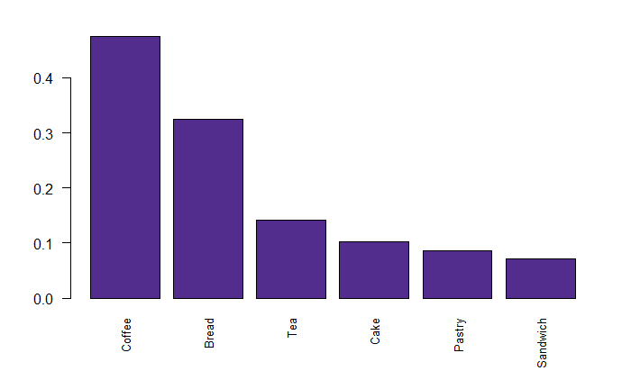

```r
#create item frequency plot of the top 6 items
IF_bb = rev(tail(sort(itemFrequency(bb_tr)), 6))
barplot(IF_bb, col='#532d8e', las=2, cex.names=0.8)
```

> Poly Purple for the main set. As suspected, coffee and bread are purchased a LOT at this store.

#### Item Frequency Tables for Time Frames

Morning Data Item Frequency Table

```r
#get rid of every column except the transaction and the items
breadbasketmorning <- MorningData %>%
  select(Transaction, Item)
#check that it worked
breadbasketmorning
```

| Transaction | Item |
| --- | --- |
| 1 | Bread |
| 2 | Scandinavian |
| 2 | Scandinavian |
| 3 | Hot chocolate |
| 3 | Jam |
| 3 | Cookies |
| 4 | Muffin |
| 5 | Coffee |
| 5 | Pastry |
| 5 | Bread |

[output cut: 990 more lines]

```r
#convert new set to transaction
bbm_tr <- as(split(breadbasketmorning[ ,"Item"], breadbasketmorning[ ,"Transaction"]), "transactions")
```

```
removing duplicated items in transactions
```

```r
inspect(bbm_tr)
```

|  | items | transactionID |
| --- | --- | --- |
| [1] | {Bread} | 1 |
| [2] | {Scandinavian} | 2 |
| [3] | {Cookies,Hot chocolate,Jam} | 3 |
| [4] | {Muffin} | 4 |
| [5] | {Bread,Coffee,Pastry} | 5 |
| [6] | {Medialuna,Muffin,Pastry} | 6 |
| [7] | {Coffee,Medialuna,Pastry,Tea} | 7 |
| [8] | {Bread,Pastry} | 8 |
| [9] | {Bread,Muffin} | 9 |
| [10] | {Medialuna,Scandinavian} | 10 |

[output cut: 990 more lines]

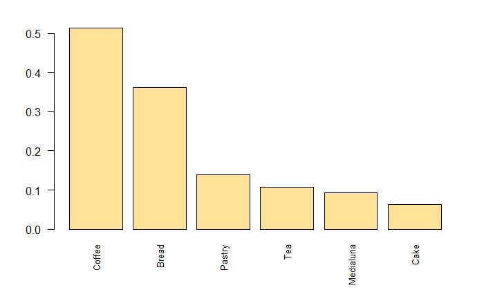

```r
#create item frequency plot of the top 6 items
IF_bbm = rev(tail(sort(itemFrequency(bbm_tr)), 6))
barplot(IF_bbm, col='#fee197', las=2, cex.names=0.8)
```

> Coffee still takes the “cake” (get it?) in the morning, which is to be expected.

Afternoon Data Item Frequency Table

```r
#get rid of every column except the transaction and the items
breadbasketafternoon <- AfternoonData %>%
  select(Transaction, Item)
#check that it worked
breadbasketafternoon
```

| Transaction | Item |
| --- | --- |
| 43 | Scandinavian |
| 43 | Fudge |
| 44 | Coffee |
| 44 | Medialuna |
| 45 | Coffee |
| 45 | Hot chocolate |
| 45 | Medialuna |
| 46 | Coffee |
| 47 | Ella's Kitchen Pouches |
| 47 | Juice |

[output cut: 990 more lines]

```r
#convert new set to transaction
bba_tr <- as(split(breadbasketafternoon[ ,"Item"], breadbasketafternoon[ ,"Transaction"]), "transactions")
```

```
removing duplicated items in transactions
```

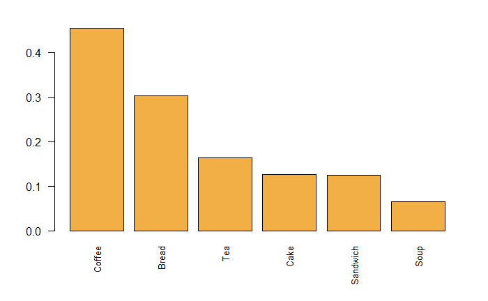

```r
#create item frequency plot of the top 6 items
IF_bba = rev(tail(sort(itemFrequency(bba_tr)), 6))
barplot(IF_bba, col='#f2af46', las=2, cex.names=0.8)
```

> Again, coffee is the most purchased. Soup makes a surprise guest appearance at the end, though.

Evening Data Item Frequency Table

```r
#get rid of every column except the transaction and the items
breadbasketevening <- EveningData %>%
  select(Transaction, Item)
#check that it worked
breadbasketevening
```

| Transaction | Item |
| --- | --- |
| 172 | Bread |
| 172 | Coffee |
| 173 | Bread |
| 173 | Muffin |
| 174 | Coffee |
| 175 | Bread |
| 176 | Cookies |
| 176 | Coffee |
| 247 | Alfajores |
| 247 | Coffee |

[output cut: 990 more lines]

```r
#convert new set to transaction
bbe_tr <- as(split(breadbasketevening[ ,"Item"], breadbasketevening[ ,"Transaction"]), "transactions")
```

```
removing duplicated items in transactions
```

```r
inspect(bbe_tr)
```

|  | items | transactionID |
| --- | --- | --- |
| [1] | {Bread,Coffee} | 172 |
| [2] | {Bread,Muffin} | 173 |
| [3] | {Coffee} | 174 |
| [4] | {Bread} | 175 |
| [5] | {Coffee,Cookies} | 176 |
| [6] | {Alfajores,Coffee,Juice} | 247 |
| [7] | {Coffee,Soup,Tea} | 248 |
| [8] | {Hot chocolate} | 249 |
| [9] | {Cookies} | 250 |
| [10] | {Coffee,Medialuna} | 251 |

[output cut: 846 more lines]

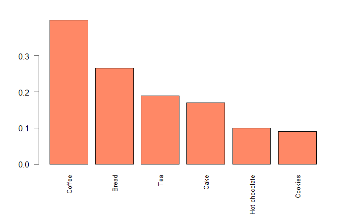

```r
#create item frequency plot of the top 6 items
IF_bbe = rev(tail(sort(itemFrequency(bbe_tr)), 6))
barplot(IF_bbe, col='#ff8866', las=2, cex.names=0.8)
```

> Evening stretches from Dinner time to midnight, so it makes sense to see a wide-ish range here. Coffee and bread vs hot chocolate and cookies.

#### Arules Anlaysis

Using the Main Dataset:

```r
#using the apriori function
breadbasketmain_rules <- apriori(bb_tr,
                                  parameter = list(support = 0.001,
                                                   confidence = 0.3)) #0.484 produces 100 rules exactly
```

```
Apriori

Parameter specification:
```

|  | confidence | minval | smax | arem | aval | originalSupport | maxtime | support | minlen | maxlen | target | ext |
| --- | --- | --- | --- | --- | --- | --- | --- | --- | --- | --- | --- | --- |
|  | 0.3 | 0.1 | 1 | none | FALSE | TRUE | 5 | 0.001 | 1 | 10 | rules | TRUE |

```
Algorithmic control:
```

|  | filter | tree | heap | memopt | load | sort | verbose |
| --- | --- | --- | --- | --- | --- | --- | --- |
|  | 0.1 | TRUE | TRUE | FALSE | TRUE | 2 | TRUE |

```
Absolute minimum support count: 9

set item appearances ...[0 item(s)] done [0.01s].
set transactions ...[94 item(s), 9531 transaction(s)] done [0.02s].
sorting and recoding items ... [57 item(s)] done [0.00s].
creating transaction tree ... done [0.00s].
checking subsets of size 1 2 3 4 done [0.03s].
writing ... [180 rule(s)] done [0.02s].
creating S4 object  ... done [0.02s].
```

```r
#exploration
inspect(sort(breadbasketmain_rules, by = "lift"))
```

|  | lhs |  | rhs | support | confidence | coverage | lift | count |
| --- | --- | --- | --- | --- | --- | --- | --- | --- |
| [1] | {Coffee,Extra Salami or Feta} | => | {Salad} | 0.001468891 | 0.4516129 | 0.003252544 | 43.4780059 | 14 |
| [2] | {Extra Salami or Feta} | => | {Salad} | 0.001678733 | 0.4210526 | 0.003986990 | 40.5358852 | 16 |
| [3] | {Alfajores,Cookies} | => | {Juice} | 0.001049208 | 0.4347826 | 0.002413178 | 11.3531864 | 10 |
| [4] | {Coke,Juice} | => | {Sandwich} | 0.001049208 | 0.4761905 | 0.002203336 | 6.6743697 | 10 |
| [5] | {Alfajores,Juice} | => | {Cookies} | 0.001049208 | 0.3448276 | 0.003042703 | 6.3816538 | 10 |
| [6] | {Coffee,Coke} | => | {Sandwich} | 0.001993495 | 0.3114754 | 0.006400168 | 4.3656943 | 19 |
| [7] | {Bread,Jammie Dodgers} | => | {Cake} | 0.001573812 | 0.3409091 | 0.004616515 | 3.3053963 | 15 |
| [8] | {Coffee,Vegan mincepie} | => | {Cake} | 0.001049208 | 0.3333333 | 0.003147624 | 3.2319430 | 10 |
| [9] | {Cake,Soup} | => | {Tea} | 0.001888574 | 0.4285714 | 0.004406673 | 3.0257143 | 18 |
| [10] | {Cake,Scone} | => | {Tea} | 0.001783653 | 0.3777778 | 0.004721435 | 2.6671111 | 17 |

[output cut: 170 more lines]

> Coffee is on the right side a lot. It is the rhs for almost every single row, which doesn’t provide anything useful. Perhaps it should be omitted.

```r
#refinement
breadbasketmain_rulessub <- subset(breadbasketmain_rules, subset =! rhs %in% "Coffee" & ! rhs %in% "Bread") #After some iteration, bread seemed too common too. We get it, everyone buys coffee and bread.

inspect(sort(breadbasketmain_rulessub, by = "lift"))
```

|  | lhs |  | rhs | support | confidence | coverage | lift | count |
| --- | --- | --- | --- | --- | --- | --- | --- | --- |
| [1] | {Coffee,Extra Salami or Feta} | => | {Salad} | 0.001468891 | 0.4516129 | 0.003252544 | 43.478006 | 14 |
| [2] | {Extra Salami or Feta} | => | {Salad} | 0.001678733 | 0.4210526 | 0.003986990 | 40.535885 | 16 |
| [3] | {Alfajores,Cookies} | => | {Juice} | 0.001049208 | 0.4347826 | 0.002413178 | 11.353186 | 10 |
| [4] | {Coke,Juice} | => | {Sandwich} | 0.001049208 | 0.4761905 | 0.002203336 | 6.674370 | 10 |
| [5] | {Alfajores,Juice} | => | {Cookies} | 0.001049208 | 0.3448276 | 0.003042703 | 6.381654 | 10 |
| [6] | {Coffee,Coke} | => | {Sandwich} | 0.001993495 | 0.3114754 | 0.006400168 | 4.365694 | 19 |
| [7] | {Bread,Jammie Dodgers} | => | {Cake} | 0.001573812 | 0.3409091 | 0.004616515 | 3.305396 | 15 |
| [8] | {Coffee,Vegan mincepie} | => | {Cake} | 0.001049208 | 0.3333333 | 0.003147624 | 3.231943 | 10 |
| [9] | {Cake,Soup} | => | {Tea} | 0.001888574 | 0.4285714 | 0.004406673 | 3.025714 | 18 |
| [10] | {Cake,Scone} | => | {Tea} | 0.001783653 | 0.3777778 | 0.004721435 | 2.667111 | 17 |

[output cut: 4 more lines]

> This is much more helpful. “Extra salami or feta” sounds like a salad add-on, so it SHOULD have a high lift if put on the lhs vs salad on the rhs. It isn’t really conducive to helpful analysis, however. There seems to be a high likelihood of customers buying a sandwhich if they buy two drinks, which could possibly indicate couples and/or families shopping here for lunch.

Main Network Diagram and Scatterplot

```r
#visualization
plot(breadbasketmain_rules, method = "graph", control = list(type = "items"),
     engine = "htmlwidget")
```

```
Unknown control parameters: type
```

[output not shown]

```
Too many rules supplied. Only plotting the best 100 rules using lift (change control parameter max if needed)
```

[interactive chart not shown]

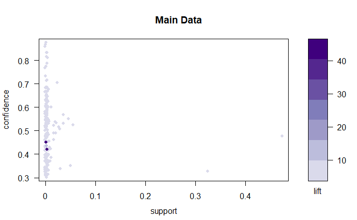

```r
#Ignore this, nothing to see here
BetterPurple <- rev(brewer.pal(9, "Purples")[3:9])

#plot of confidence against support, colored by lift
plot(breadbasketmain_rules, main="Main Data", col=palette(BetterPurple), shading="lift")
```

> The network doesn’t seem to have any visually-distinct clusters. Coffee just seems to have about 5 million arrows pointing at it, which makes sense because it is bought so much more than everything else.

Main Subset Network Diagram and Scatterplot

```r
#visualization
plot(breadbasketmain_rulessub, method = "graph", control = list(type = "items"),
     engine = "htmlwidget")
```

```
Unknown control parameters: type
```

[output not shown]

[interactive chart not shown]

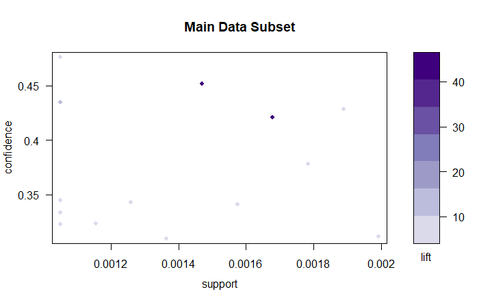

```r
#plot of confidence against support, colored by lift
plot(breadbasketmain_rulessub, main="Main Data Subset", col=palette(BetterPurple), shading="lift")
```

> As the above analysis indicated, “Extra salami or feta” is clustered with salad, and coke is clustered with sandwich.

Using the Morning Dataset:

```r
#using the apriori function
breadbasketmorn_rules <- apriori(bbm_tr,
                                  parameter = list(support = 0.001,
                                                   confidence = 0.3))
```

```
Apriori

Parameter specification:
```

|  | confidence | minval | smax | arem | aval | originalSupport | maxtime | support | minlen | maxlen | target | ext |
| --- | --- | --- | --- | --- | --- | --- | --- | --- | --- | --- | --- | --- |
|  | 0.3 | 0.1 | 1 | none | FALSE | TRUE | 5 | 0.001 | 1 | 10 | rules | TRUE |

```
Algorithmic control:
```

|  | filter | tree | heap | memopt | load | sort | verbose |
| --- | --- | --- | --- | --- | --- | --- | --- |
|  | 0.1 | TRUE | TRUE | FALSE | TRUE | 2 | TRUE |

```
Absolute minimum support count: 4

set item appearances ...[0 item(s)] done [0.01s].
set transactions ...[76 item(s), 4111 transaction(s)] done [0.02s].
sorting and recoding items ... [48 item(s)] done [0.00s].
creating transaction tree ... done [0.00s].
checking subsets of size 1 2 3 4 done [0.02s].
writing ... [162 rule(s)] done [0.01s].
creating S4 object  ... done [0.01s].
```

```r
breadbasketmorn_rulessub <- subset(breadbasketmorn_rules, subset =! rhs %in% "Coffee" & ! rhs %in% "Bread")
#exploration
inspect(sort(breadbasketmorn_rulessub, by = "lift"))
```

|  | lhs |  | rhs | support | confidence | coverage | lift | count |
| --- | --- | --- | --- | --- | --- | --- | --- | --- |
| [1] | {Coffee,Jammie Dodgers} | => | {Juice} | 0.001702749 | 0.3888889 | 0.004378497 | 12.203986 | 7 |
| [2] | {Bread,Jammie Dodgers} | => | {Cake} | 0.001216249 | 0.4545455 | 0.002675748 | 7.214812 | 5 |
| [3] | {Coffee,Muffin,Tea} | => | {Cake} | 0.001459499 | 0.4285714 | 0.003405497 | 6.802537 | 6 |
| [4] | {Medialuna,Toast} | => | {Hot chocolate} | 0.001216249 | 0.3333333 | 0.003648747 | 6.314900 | 5 |
| [5] | {Cake,Coffee,Muffin} | => | {Tea} | 0.001459499 | 0.6666667 | 0.002189248 | 6.214664 | 6 |
| [6] | {Coffee,Muffin,Pastry} | => | {Tea} | 0.001216249 | 0.6250000 | 0.001945999 | 5.826247 | 5 |
| [7] | {Coffee,Farm House,Pastry} | => | {Medialuna} | 0.001216249 | 0.5000000 | 0.002432498 | 5.409211 | 5 |
| [8] | {Cake,Toast} | => | {Tea} | 0.001216249 | 0.5555556 | 0.002189248 | 5.178886 | 5 |
| [9] | {Juice,Muffin} | => | {Tea} | 0.001459499 | 0.4285714 | 0.003405497 | 3.995141 | 6 |
| [10] | {Coffee,Farm House,Medialuna} | => | {Pastry} | 0.001216249 | 0.5555556 | 0.002189248 | 3.992813 | 5 |

[output cut: 9 more lines]

> Subsetted prior to analysis. Unfortunately, it is hard to take away anything solid from this. I do find it interesting that I don’t see jam on this list. I would think it would go with toast quite a bit!

Morning Network Diagram and Scatterplot

```r
#visualization
plot(breadbasketmorn_rulessub, method = "graph", control = list(type = "items"),
     engine = "htmlwidget")
```

```
Unknown control parameters: type
```

[output not shown]

[interactive chart not shown]

[figure not shown]

```r
plot(breadbasketmain_rulessub, main="Morning Data Subset", col=palette(rev(brewer.pal(4, "YlOrRd")[1:4])), shading="lift")
```

Nothing stands out about this network. Many arrows point to tea, which makes sense as it is one of the most frequently purchased items.

Using the Afternoon Dataset

```r
#using the apriori function
breadbasketaft_rules <- apriori(bba_tr,
                                  parameter = list(support = 0.001,
                                                   confidence = 0.3))
```

```
Apriori

Parameter specification:
```

|  | confidence | minval | smax | arem | aval | originalSupport | maxtime | support | minlen | maxlen | target | ext |
| --- | --- | --- | --- | --- | --- | --- | --- | --- | --- | --- | --- | --- |
|  | 0.3 | 0.1 | 1 | none | FALSE | TRUE | 5 | 0.001 | 1 | 10 | rules | TRUE |

```
Algorithmic control:
```

|  | filter | tree | heap | memopt | load | sort | verbose |
| --- | --- | --- | --- | --- | --- | --- | --- |
|  | 0.1 | TRUE | TRUE | FALSE | TRUE | 2 | TRUE |

```
Absolute minimum support count: 4

set item appearances ...[0 item(s)] done [0.00s].
set transactions ...[85 item(s), 4564 transaction(s)] done [0.01s].
sorting and recoding items ... [54 item(s)] done [0.01s].
creating transaction tree ... done [0.00s].
checking subsets of size 1 2 3 4 done [0.02s].
writing ... [309 rule(s)] done [0.01s].
creating S4 object  ... done [0.01s].
```

```r
breadbasketaft_rulessub <- subset(breadbasketaft_rules, subset =! rhs %in% "Coffee" & ! rhs %in% "Bread")
#exploration
inspect(sort(breadbasketaft_rules, by = "lift"))
```

|  | lhs |  | rhs | support | confidence | coverage | lift | count |
| --- | --- | --- | --- | --- | --- | --- | --- | --- |
| [1] | {Bread,Salad} | => | {Extra Salami or Feta} | 0.001095530 | 0.3125000 | 0.003505697 | 54.8557692 | 5 |
| [2] | {Bread,Extra Salami or Feta} | => | {Salad} | 0.001095530 | 0.7142857 | 0.001533742 | 38.3529412 | 5 |
| [3] | {Coffee,Extra Salami or Feta} | => | {Salad} | 0.002629273 | 0.6000000 | 0.004382121 | 32.2164706 | 12 |
| [4] | {Extra Salami or Feta} | => | {Salad} | 0.003067485 | 0.5384615 | 0.005696757 | 28.9122172 | 14 |
| [5] | {Duck egg} | => | {Spanish Brunch} | 0.001095530 | 0.6250000 | 0.001752848 | 23.5743802 | 5 |
| [6] | {Coffee,Crisps} | => | {Juice} | 0.001095530 | 0.8333333 | 0.001314636 | 19.9127400 | 5 |
| [7] | {Crisps} | => | {Juice} | 0.001095530 | 0.5000000 | 0.002191060 | 11.9476440 | 5 |
| [8] | {Sandwich,Spanish Brunch} | => | {Truffles} | 0.001095530 | 0.3125000 | 0.003505697 | 10.5648148 | 5 |
| [9] | {Sandwich,Spanish Brunch} | => | {Juice} | 0.001095530 | 0.3125000 | 0.003505697 | 7.4672775 | 5 |
| [10] | {Bread,Coffee,Scone} | => | {Hot chocolate} | 0.001095530 | 0.3846154 | 0.002848379 | 7.0497374 | 5 |

[output cut: 299 more lines]

> Some very high lifts. This could indicate that the “extra salami or feta” add-on is quite popular. When paired with bread and salad, it has the highest lift of any rule so far (at least in the subsets). People who buy chips are also likely to purchase juice, and people who buy coffee AND chips are even more so.

Afternoon Network Diagram and Scatterplot

```r
#visualization
plot(breadbasketaft_rulessub, method = "graph", control = list(type = "items"),
     engine = "htmlwidget")
```

```
Unknown control parameters: type
```

[output not shown]

[interactive chart not shown]

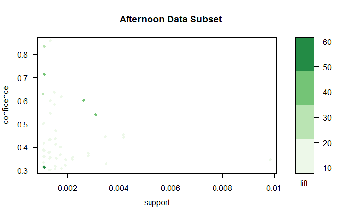

```r
plot(breadbasketaft_rulessub, main="Afternoon Data Subset", col=palette(rev(brewer.pal(4, "Greens")[1:4])), shading="lift")
```

> Again, there are clusters around the popular items (cake, tea, etc.) Interestingly, there are a decent number of rules involving hot chocolate for a set of afternoon purchases.

Using the Evening Dataset:

```r
#using the apriori function
breadbasketeve_rules <- apriori(bbe_tr,
                                  parameter = list(support = 0.001,
                                                   confidence = 0.3))
```

```
Apriori

Parameter specification:
```

|  | confidence | minval | smax | arem | aval | originalSupport | maxtime | support | minlen | maxlen | target | ext |
| --- | --- | --- | --- | --- | --- | --- | --- | --- | --- | --- | --- | --- |
|  | 0.3 | 0.1 | 1 | none | FALSE | TRUE | 5 | 0.001 | 1 | 10 | rules | TRUE |

```
Algorithmic control:
```

|  | filter | tree | heap | memopt | load | sort | verbose |
| --- | --- | --- | --- | --- | --- | --- | --- |
|  | 0.1 | TRUE | TRUE | FALSE | TRUE | 2 | TRUE |

```
Absolute minimum support count: 0

set item appearances ...[0 item(s)] done [0.01s].
set transactions ...[68 item(s), 856 transaction(s)] done [0.01s].
sorting and recoding items ... [68 item(s)] done [0.01s].
creating transaction tree ... done [0.00s].
checking subsets of size 1 2 3 4 5 6 7 8 9 10 done [0.05s].
writing ... [8065 rule(s)] done [0.01s].
creating S4 object  ... done [0.01s].
```

```r
breadbasketeve_rulessub <- subset(breadbasketeve_rules, subset =! rhs %in% "Coffee" & ! rhs %in% "Bread")
#exploration (this took some iteration)
inspect(sort(breadbasketeve_rulessub, by = "lift"))
```

|  | lhs |  | rhs | support | confidence | coverage | lift | count |
| --- | --- | --- | --- | --- | --- | --- | --- | --- |
| [1] | {The Nomad} | => | {Duck egg} | 0.001168224 | 1.0000000 | 0.001168224 | 856.00000 | 1 |
| [2] | {Duck egg} | => | {The Nomad} | 0.001168224 | 1.0000000 | 0.001168224 | 856.00000 | 1 |
| [3] | {Chicken Stew,Coffee} | => | {Extra Salami or Feta} | 0.001168224 | 1.0000000 | 0.001168224 | 856.00000 | 1 |
| [4] | {Tea,The Nomad} | => | {Duck egg} | 0.001168224 | 1.0000000 | 0.001168224 | 856.00000 | 1 |
| [5] | {Duck egg,Tea} | => | {The Nomad} | 0.001168224 | 1.0000000 | 0.001168224 | 856.00000 | 1 |
| [6] | {Coffee,The Nomad} | => | {Duck egg} | 0.001168224 | 1.0000000 | 0.001168224 | 856.00000 | 1 |
| [7] | {Coffee,Duck egg} | => | {The Nomad} | 0.001168224 | 1.0000000 | 0.001168224 | 856.00000 | 1 |
| [8] | {Bare Popcorn,Sandwich} | => | {Crisps} | 0.001168224 | 1.0000000 | 0.001168224 | 856.00000 | 1 |
| [9] | {Bare Popcorn,Hot chocolate} | => | {Crisps} | 0.001168224 | 1.0000000 | 0.001168224 | 856.00000 | 1 |
| [10] | {Bare Popcorn,Cookies} | => | {Crisps} | 0.001168224 | 1.0000000 | 0.001168224 | 856.00000 | 1 |

[output cut: 990 more lines]

> I have no idea what “The Nomad” is and I really hope “duck egg” isn’t what it sounds like. These lift values are extremely high, probably because the counts for all these transactions are “1”. Subset time.

```r
#Subsetting (iterated upon)
breadbasketeve_rulessub <- subset(breadbasketeve_rulessub, subset = count > 5)

inspect(sort(breadbasketeve_rulessub, by = "lift"))
```

|  | lhs |  | rhs | support | confidence | coverage | lift | count |
| --- | --- | --- | --- | --- | --- | --- | --- | --- |
| [1] | {Postcard} | => | {Tshirt} | 0.007009346 | 0.6000000 | 0.011682243 | 24.457143 | 6 |
| [2] | {Alfajores,Bread} | => | {Brownie} | 0.007009346 | 0.4000000 | 0.017523364 | 7.443478 | 6 |
| [3] | {Bread,Brownie} | => | {Alfajores} | 0.007009346 | 0.5000000 | 0.014018692 | 7.254237 | 6 |
| [4] | {Mineral water} | => | {Alfajores} | 0.007009346 | 0.3333333 | 0.021028037 | 4.836158 | 6 |
| [5] | {Cake,Scone} | => | {Tea} | 0.008177570 | 0.8750000 | 0.009345794 | 4.623457 | 7 |
| [6] | {Scone,Tea} | => | {Cake} | 0.008177570 | 0.6363636 | 0.012850467 | 3.731009 | 7 |
| [7] | {Coffee,Juice} | => | {Cookies} | 0.007009346 | 0.3157895 | 0.022196262 | 3.510595 | 6 |
| [8] | {Juice} | => | {Cookies} | 0.015186916 | 0.3023256 | 0.050233645 | 3.360918 | 13 |
| [9] | {Bread,Brownie} | => | {Tea} | 0.007009346 | 0.5000000 | 0.014018692 | 2.641975 | 6 |
| [10] | {Pastry} | => | {Tea} | 0.012850467 | 0.4230769 | 0.030373832 | 2.235518 | 11 |

[output cut: 12 more lines]

> Tshirts are frequently bought when postcards are bought. This makes sense, as they are both souveneirs. However, with only six actual transactions, this should not be treated as “conclusive”.

Evening Network Diagram and Scatterplot

```r
#visualization
plot(breadbasketeve_rulessub, method = "graph", control = list(type = "items"),
     engine = "htmlwidget")
```

```
Unknown control parameters: type
```

[output not shown]

[interactive chart not shown]

[figure not shown]

```r
plot(breadbasketaft_rulessub, main="Evening Data Subset", col=palette(rev(brewer.pal(4, "Blues"))), shading="lift")
```

> There are a couple interesting visuals here. It would appear the only transactions (in this subset) involving postcards and tshirts are of rule 1. As it is one of the most popular items in general and during this time period, tea again has many arrows pointing towards it.

## Discussion

Through exploration, we were able to see that transactions generally occurred between 07:00 and 23:00, with one a little after 01:00. As a side note, this was relatively challenging to convert to a properly formatted transaction database even though it is already kind of set up like one. After completing our frequency analysis, we discovered that coffee was the most popular item for the main data set and was the most-purchased item for morning, afternoon, and evening. We also found that, because coffee and bread vastly outnumbered the other items, the rhs of the rules were dominated by them. We had to create subsets that banned those from the rhs to get any kind of meaningful analysis.

As one would expect, the most popular items seem to have their own clusters in the network diagrams. You can also see some other common-sense combinations, such as the salad with extra salami or feta, along with some that might be overlooked, like the postcard with the t-shirt. However, the rest is hard to interpret. Most of the associations involve 2 or more items in the lhs, and we don’t even know what some of the items are. The economics of food also make analysis of the situation complex, as some foods are primary goods, some are complementary, some are substitutes, and some are a little of each. Looking at the scatter plots of confidence against support, there doesn’t seem to be a very wide range of support. This makes sense, as there are a lot of different items and thousands of transactions.

## Conclusion

Coffee appears to be a popular product at any time of day. Based on the arules analysis, the store may be able to make some stocking decisions to encourage the purchase of certain products. However, at least in the eyes of 4 inexperienced data miners, most of the associations we found do not seem particularly useful.